# Research compendia as R packages

Scientific workflows: Tools and Tips 🛠️

2023-07-20

## What is this lecture series?

### Scientific workflows: Tools and Tips 🛠️

📅 Every 3rd Thursday 🕓 4-5 p.m. 📍 Webex

- One topic from the world of scientific workflows
- For topic suggestions send me an email
- If you don’t want to miss a lecture
  - Check out the [lecture website](https://www.bcp.fu-berlin.de/en/graduiertenzentrum/promovierende/veranstaltungen/workshops/lecture-SB/index.html)
  - [Subscribe to the mailing list](https://lists.fu-berlin.de/listinfo/toolsAndTips)
- Slides provided [on Github](https://selinazitrone.github.io/tools_and_tips/)

## Steps of a scientific project

[figure not shown]

This image was created by [Scriberia](http://www.scriberia.co.uk/) for The Turing Way community and is used under a CC-BY licence (DOI 10.5281/zenodo.3332807).

## Steps of a scientific project

How to properly structure the project?

I want

- 🔃 Reproduciblity (for you and others)
- 🏋 Reliablity (will it work again?)
- ⚙ Re-usablity (don’t re-invent the wheel)
- 🔍 Visiblity (let others see and use your work)

## How? Use a research compendium!

[figure not shown]

This image was created by [Scriberia](http://www.scriberia.co.uk/) for The Turing Way community and is used under a CC-BY licence (DOI 10.5281/zenodo.3332807).

#### What is a research compendium?

- Collection of all digital parts of a research project (data + code + text)

> The goal of a research compendium is to provide a **standard and easily recognizable** way for organizing the digital materials of a project to enable others to **inspect, reproduce, and extend** the research.

From [Marwick et al. 2018](https://doi.org/10.1080/00031305.2017.1375986.)

## Principles for building research compendia

- Stick with the conventions in your field
- Keep **data**, **methods** and **output** separate
- Specify the computational environment
- Key components for sharing the compendium include
  - Licence
  - Version control
  - Metadata
  - Persistent identifier (e.g DOI)

## Examples of different complexities

Small compendium

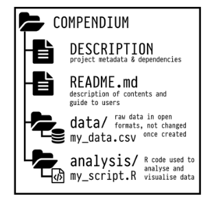

Medium size compendium

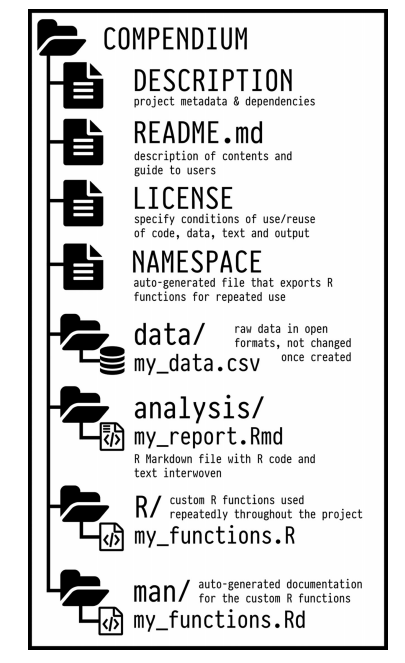

They are R packages!

Marwick et al. 2018

## R packages as research compendia

[figure not shown]

**Basic idea:** Hijack the R package development ecosystem to build a research compendium

Different use cases, e.g.

- Publish code, data and analysis scripts alongside your paper
- Publish a dataset in a way that other people can work with it in R

## Some benefits of R packages

- Benefit from quality control mechanisms built around R packages
- Additional packages around this ecosystem to make your life easier
- Easy documentation
- Easy sharing of data

# Hands-on: Create a research compendium with the R package structure

## Summary and Conclusions

It’s convenient to have standards you can follow

- R packages provide an helpful development ecosystem that we can hijack for our research compendia
- You can develop your compendium in different ways
  - A package that is meant to be installed with `install.packages()`
  - A compendium that won’t be installed but uses quality checks from package ecosystem
- `usethis` is a great workflow package (not only for package development)

## Outlook

- Include large datasets with piggyback
- Automated tests with [Github actions](https://docs.github.com/en/actions)
- Unit tests to test your functions using [testthat](https://testthat.r-lib.org/)
- Easily [connect Github repo to Zenodo](https://emilio-berti.github.io/idiv-git-introduction/21-github_zenodo/index.html) to get a DOI
- [holepunch package](https://karthik.github.io/holepunch/) to build a Docker image

The nice thing:

- Also this easy to set up with `usethis` and friends
- They are also documented on the lecture series website

## Next lecture

Summer/Conference break in August and September!

Time for some feedback from you!

Please fill out [the questionnaire](https://forms.gle/xyfNfqd3Ver1Yppq8) if you have time (5 mins)

### Topic of next lecture t.b.a.

📅 19th October 🕓 4-5 p.m. 📍 Webex

🔔 [Subscribe to the mailing list](https://lists.fu-berlin.de/listinfo/toolsAndTips)

📧 For topic suggestions and/or feedback send me an email

## Thank you for your attention :)

Questions?

## References

- Marwick, Ben, Carl Boettiger, and Lincoln Mullen. 2018. “Packaging Data Analytical Work Reproducibly Using R (and Friends).” American Statistician 72 (1): 80–88. [https://doi.org/10.1080/00031305.2017.1375986.](https://doi.org/10.1080/00031305.2017.1375986)
- [The Turing Way website](https://the-turing-way.netlify.app/introduction/introduction.html) is a very useful guide to reproducible data science
- [Slides and list of resources for research compendia by Karthik](https://inundata.org/talks/rstudio2019/)